# Modelo

Gabriel Granda

3/2/2022

```r
## Librerías
library(readxl)
library(tidyverse)
```

```r
library(naniar)
library(ggplot2)
library(dplyr)
library(tidyr)
library(eeptools)
```

Leemos los datos donde se encuentra la información consolidada:

```r
ruta4<- "C:\\Users\\GABRIEL\\OneDrive\\Documents\\Trabajo\\datos_hakaton.xlsx"
clientes<- as.data.frame(read_xlsx(ruta4))
```

Con esto, el número de clientes en la base de datos después de los filtros es:

```r
dim(clientes)[1]
```

```
## [1] 20935
```

Ahora, borramos las variables de Surname, Geography, application_date, exit_date, birth_date y tiempo, las cuales son variables que no aportan al modelo:

```r
clientes<- clientes %>% select(-Surname,-Geography,-application_date,-exit_date,-birth_date,-Tiempo)
```

Ahora, tanto para la realización del modelo estadístico como el análisis estadístico de las variables, vamos a eliminar aquellas observaciones que poseen valores faltantes.

```r
clientes<- na.omit(clientes)
clientes<- clientes %>% select(-CustomerId)
```

Por otro lado, al eliminar los valores faltantes para entrenar el modelo, contamos con

```r
dim(clientes)[1]
```

```
## [1] 19910
```

Transformamos las variables HasCrCard e IsActiveMember a variables del tipo factor:

```r
clientes$HasCrCard<- as.factor(clientes$HasCrCard)
clientes$IsActiveMember<- as.factor(clientes$IsActiveMember)
```

Para las variables numéricas presentamos su distribución:

```r
library(caret)
```

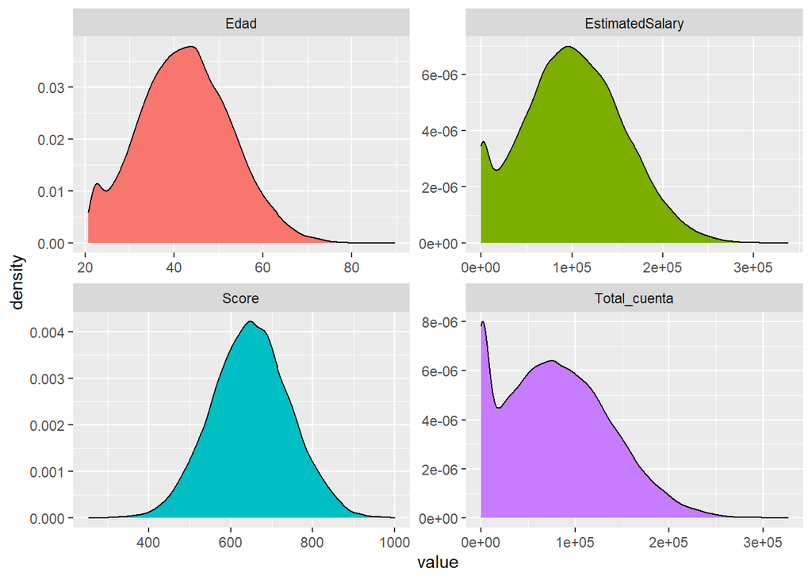

```r
clientes%>%
  select(EstimatedSalary,Score,Total_cuenta,Edad) %>%
  gather(metric, value) %>%
  ggplot(aes(value, fill = metric)) +
  geom_density(show.legend = FALSE) +
  facet_wrap(~ metric, scales = "free")
```

Para el salario estimado, tenemos que

```r
c('Min' = min(clientes$EstimatedSalary), 'Q1'=quantile(clientes$EstimatedSalary,0.25),
  'Mediana'=median(clientes$EstimatedSalary), 'Mean'=mean(clientes$EstimatedSalary), 'Q3'=quantile(clientes$EstimatedSalary,0.75),
  'Máx'=max(clientes$EstimatedSalary), 'Rango'=max(clientes$EstimatedSalary)-min(clientes$EstimatedSalary), 'Desv.est'=sd(clientes$EstimatedSalary))
```

```
##       Min    Q1.25%   Mediana      Mean    Q3.75%       Máx     Rango  Desv.est
##      0.00  61851.77  99508.32 100673.33 138527.26 337304.44 337304.44  55472.32
```

Para score, tenemos que

```r
c('Min' = min(clientes$Score), 'Q1'=quantile(clientes$Score,0.25),
  'Mediana'=median(clientes$Score), 'Mean'=mean(clientes$Score), 'Q3'=quantile(clientes$Score,0.75),
  'Máx'=max(clientes$Score), 'Rango'=max(clientes$Score)-min(clientes$Score), 'Desv.est'=sd(clientes$Score))
```

```
##        Min     Q1.25%    Mediana       Mean     Q3.75%        Máx      Rango
##  252.00000  585.00000  649.00000  649.28518  713.00000 1000.00000  748.00000
##   Desv.est
##   95.63316
```

Podemos ver que la mediana está muy cerca de la media, lo cual explica porque la distribucón de esta variable es simétrica.

Para número de productos:

```r
c('Min' = min(clientes$Num_Productos), 'Q1'=quantile(clientes$Num_Productos,0.25),
  'Mediana'=median(clientes$Num_Productos), 'Mean'=mean(clientes$Num_Productos), 'Q3'=quantile(clientes$Num_Productos,0.75),
  'Máx'=max(clientes$Num_Productos), 'Rango'=max(clientes$Num_Productos)-min(clientes$Num_Productos), 'Desv.est'=sd(clientes$Num_Productos))
```

```
##      Min   Q1.25%  Mediana     Mean   Q3.75%      Máx    Rango Desv.est
## 1.000000 2.000000 2.000000 2.498644 3.000000 4.000000 3.000000 1.113515
```

Para saldo total en la cuenta:

```r
options(scipen=999)

c('Min' = min(clientes$Total_cuenta), 'Q1'=quantile(clientes$Total_cuenta,0.25),
  'Mediana'=median(clientes$Total_cuenta), 'Mean'=mean(clientes$Total_cuenta), 'Q3'=quantile(clientes$Total_cuenta,0.75),
  'Máx'=max(clientes$Total_cuenta), 'Rango'=max(clientes$Total_cuenta)-min(clientes$Total_cuenta), 'Desv.est'=sd(clientes$Total_cuenta))
```

```
##                        Min                     Q1.25%
##     -0.0000000000009094947  33819.7800000000061118044
##                    Mediana                       Mean
##  76018.1549999999988358468  79414.2623771973885595798
##                     Q3.75%                        Máx
## 118065.0000000000000000000 326141.9099999999743886292
##                      Rango                   Desv.est
## 326141.9099999999743886292  56197.3534222528614918701
```

Para edad:

```r
c('Min' = min(clientes$Edad), 'Q1'=quantile(clientes$Edad,0.25),
  'Mediana'=median(clientes$Edad), 'Mean'=mean(clientes$Edad), 'Q3'=quantile(clientes$Edad,0.75),
  'Máx'=max(clientes$Edad), 'Rango'=max(clientes$Edad)-min(clientes$Edad), 'Desv.est'=sd(clientes$TEdad))
```

```
##      Min   Q1.25%  Mediana     Mean   Q3.75%      Máx    Rango Desv.est
## 20.69863 35.30685 42.33699 42.48983 49.48316 89.61499 68.91636       NA
```

Ahora, presentamos la tabla de distribución de frecuencias para las variables categóricas:

```r
library(questionr)
freq(clientes$Gender)
```

```
##            n    % val%
## Female 10047 50.5 50.5
## Male    9863 49.5 49.5
```

Vemos que hay más mujeres que hombres, sin embargo, esta diferencia es mínima.

```r
freq(clientes$HasCrCard)
```

```
##       n    % val%
## 0 10085 50.7 50.7
## 1  9825 49.3 49.3
```

Aproximadamente, el 50.7% de los clientes no tiene tarjeta de crédito, mientras que el 49.3% si posee una tarjeta.

Finalmente, analicemos la variable tarjet que nos servirá para hacer la clasificación:

```r
freq(clientes$IsActiveMember)
```

```
##      n  % val%
## 0 9964 50   50
## 1 9946 50   50
```

Vemos que el número de personas que mantienen el serviciio es el mismo de las personas que ya no tienen el servicio. Así, nuestros datos son equilibrados.

Transformamos las variables categóricas a dummies:

```r
library(fastDummies)

categoricas <- c("Gender","HasCrCard" )

clientes_logit <- clientes %>% dummy_cols(select_columns = categoricas)  %>% select(-categoricas)
```

```
## Note: Using an external vector in selections is ambiguous.
## i Use `all_of(categoricas)` instead of `categoricas` to silence this message.
## i See <https://tidyselect.r-lib.org/reference/faq-external-vector.html>.
```

Ahora, vamos a dividir lo datos en 80%-20%, el 80% corresponderá a los datos empleados para el entrenamiento del modelo, mientras que el 20% nos servirá para la validación del mismo.

```r
### Fijamos el semillero:

set.seed(1234)

entrenamiento <- sample_frac(clientes_logit, .8)

val <- setdiff(clientes_logit, entrenamiento)
```

Así, presentamos el siguiente modelo de regresión logística:

```r
modelo_logistico <- glm(IsActiveMember~., data = entrenamiento, family = "binomial")

summary(modelo_logistico)
```

```
##
## Call:
## glm(formula = IsActiveMember ~ ., family = "binomial", data = entrenamiento)
##
## Deviance Residuals:
##    Min      1Q  Median      3Q     Max
## -1.209  -1.175  -1.147   1.179   1.213
##
## Coefficients: (2 not defined because of singularities)
##                       Estimate     Std. Error z value Pr(>|z|)
## (Intercept)      0.04134071379  0.13765414623   0.300    0.764
## EstimatedSalary -0.00000003205  0.00000028450  -0.113    0.910
## Score           -0.00011739269  0.00016534767  -0.710    0.478
## Num_Productos    0.00951757450  0.01429897954   0.666    0.506
## Total_cuenta    -0.00000027463  0.00000028165  -0.975    0.330
## Edad             0.00065801352  0.00154266805   0.427    0.670
## Gender_Female    0.00304104497  0.03170401184   0.096    0.924
## Gender_Male                 NA             NA      NA       NA
## HasCrCard_0      0.00354289105  0.03170540600   0.112    0.911
## HasCrCard_1                 NA             NA      NA       NA
##
## (Dispersion parameter for binomial family taken to be 1)
##
##     Null deviance: 22081  on 15927  degrees of freedom
## Residual deviance: 22079  on 15920  degrees of freedom
## AIC: 22095
##
## Number of Fisher Scoring iterations: 3
```

```r
modelo_logistico1 <- glm(IsActiveMember ~ EstimatedSalary + Score + Num_Productos + Total_cuenta +
    Edad + Gender_Male + HasCrCard_0 , data = entrenamiento, family = "binomial")

summary(modelo_logistico1)
```

```
##
## Call:
## glm(formula = IsActiveMember ~ EstimatedSalary + Score + Num_Productos +
##     Total_cuenta + Edad + Gender_Male + HasCrCard_0, family = "binomial",
##     data = entrenamiento)
##
## Deviance Residuals:
##    Min      1Q  Median      3Q     Max
## -1.209  -1.175  -1.147   1.179   1.213
##
## Coefficients:
##                       Estimate     Std. Error z value Pr(>|z|)
## (Intercept)      0.04438175876  0.13758554512   0.323    0.747
## EstimatedSalary -0.00000003205  0.00000028450  -0.113    0.910
## Score           -0.00011739269  0.00016534767  -0.710    0.478
## Num_Productos    0.00951757450  0.01429897954   0.666    0.506
## Total_cuenta    -0.00000027463  0.00000028165  -0.975    0.330
## Edad             0.00065801352  0.00154266805   0.427    0.670
## Gender_Male     -0.00304104497  0.03170401184  -0.096    0.924
## HasCrCard_0      0.00354289105  0.03170540600   0.112    0.911
##
## (Dispersion parameter for binomial family taken to be 1)
##
##     Null deviance: 22081  on 15927  degrees of freedom
## Residual deviance: 22079  on 15920  degrees of freedom
## AIC: 22095
##
## Number of Fisher Scoring iterations: 3
```

Además, podemos ver que las variables no son significativas pues los p-valores son mayores a 0.05.

Con esto en mente, presentemos un modelo de Random Forest:

```r
set.seed(1234)

entrenamiento1 <- sample_frac(clientes, .8)

val1 <- setdiff(clientes, entrenamiento1)



library(randomForest)
t1 <- proc.time()

mod1 <- randomForest(IsActiveMember~., data=entrenamiento1,set.seed(1714))

t1total<- proc.time()-t1

mod1
```

```
##
## Call:
##  randomForest(formula = IsActiveMember ~ ., data = entrenamiento1,      set.seed(1714))
##                Type of random forest: classification
##                      Number of trees: 500
## No. of variables tried at each split: 2
##
##         OOB estimate of  error rate: 49.6%
## Confusion matrix:
##      0    1 class.error
## 0 3925 4058   0.5083302
## 1 3842 4103   0.4835746
```

```r
CM1<-confusionMatrix(predict(mod1, val1), val1$IsActiveMember)
CM1
```

```
## Confusion Matrix and Statistics
##
##           Reference
## Prediction    0    1
##          0  930  953
##          1 1051 1048
##
##                Accuracy : 0.4967
##                  95% CI : (0.4811, 0.5124)
##     No Information Rate : 0.5025
##     P-Value [Acc > NIR] : 0.77181
##
##                   Kappa : -0.0068
##
##  Mcnemar's Test P-Value : 0.03025
##
##             Sensitivity : 0.4695
##             Specificity : 0.5237
##          Pos Pred Value : 0.4939
##          Neg Pred Value : 0.4993
##              Prevalence : 0.4975
##          Detection Rate : 0.2336
##    Detection Prevalence : 0.4729
##       Balanced Accuracy : 0.4966
##
##        'Positive' Class : 0
##
```

Además, el acurrancy es:

```r
CM1$overall[1]
```

```
##  Accuracy
## 0.4967353
```

Por otro lado, para la base de entrenamiento, obtenemos que

```r
CM2<-confusionMatrix(predict(mod1, entrenamiento1), entrenamiento1$IsActiveMember)
CM2
```

```
## Confusion Matrix and Statistics
##
##           Reference
## Prediction    0    1
##          0 7983    1
##          1    0 7944
##
##                Accuracy : 0.9999
##                  95% CI : (0.9997, 1)
##     No Information Rate : 0.5012
##     P-Value [Acc > NIR] : <0.0000000000000002
##
##                   Kappa : 0.9999
##
##  Mcnemar's Test P-Value : 1
##
##             Sensitivity : 1.0000
##             Specificity : 0.9999
##          Pos Pred Value : 0.9999
##          Neg Pred Value : 1.0000
##              Prevalence : 0.5012
##          Detection Rate : 0.5012
##    Detection Prevalence : 0.5013
##       Balanced Accuracy : 0.9999
##
##        'Positive' Class : 0
##
```

Además, consideremos el gráfico de error vs el número de árboles:

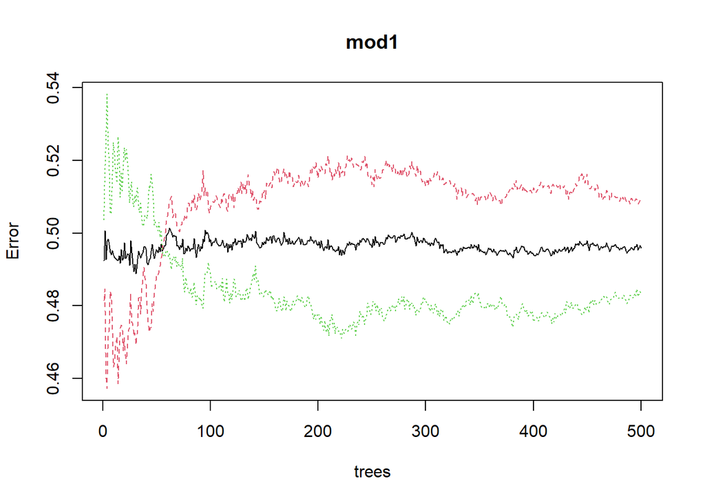

```r
plot(mod1)
```

Podemos ver como el error se estabiliza a partir de 300 árboles.

Grafiquemos también la importancia de las variables:

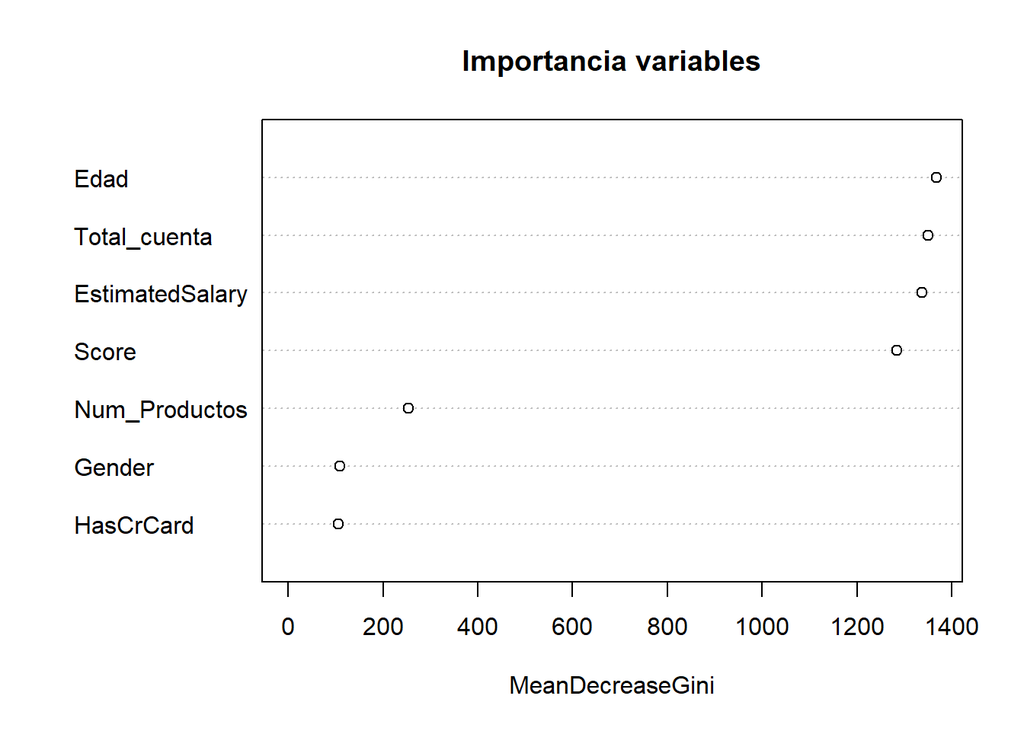

```r
varImpPlot(mod1,type=2,main="Importancia variables")
```

Tenemos que las variables Edad, Total Cuenta, Salario Estimado y Score son las variables que tienen más peso para realizar la clasificación.

Para validar el modelo se emplea la matriz de confusión, también podemos utilizar la Curva ROC, la cual sirve evaluar la capacidad de un modelo de regresión logística binaria para clasificar con exactitud las observaciones. Una curva ROC se construye generando varias tablas de clasificación, para valores de corte que oscilan entre 0 y 1 y calculando la sensibilidad y la especificidad para cada valor. La sensibilidad se grafica en función de la especificidad para construir una curva ROC.